# Chapter 6: Optimization

**Goals**

- Gain a basic understanding of numerical optimization algorithms
- Get familiar with the `scipy.optimize` library
- Apply this knowledge to fit a linear regression model

## 6.1 Some Basic Concepts and Vocabulary

Optimization generally refers to finding some **value** of a variable (e.g. `x`) that produces an **optimal** outcome of a function (e.g. `y`). First, we have to understand what *optimal* is actually supposed to mean:

- Sometimes, we try to **minimize** a function, i.e. find the value of `x` so that `y` takes its **lowest** outcome. Example: Find the perfect amount of cups of coffee per day to minimize the time it takes to solve a reference task (caution: Drink too much and all you get is heavy sweating).
- Other times, we try to **maximize** a function, i.e. find the value of `x` so that `y` takes its **highest** outcome. Example: Find the perfect amount of sugar per cup of coffee to maximize flavor.

Let's look at a simple example, where we try to **minimize** the function $y = (x-1)^2 + 2$. Obviously (well hopefully), you quickly realize, that the **analytical minimum** is located at $x=1, y=2$. We know this, because we can analytically find the derivative and its zero crossing. In general though, this is not so easy due to various reasons:

1. We do not have an analytical expression for $y(x)$ but only a tool for evaluating single points $y_i(x_i)$
2. We do have $y(x)$, but the derivative is hard to come by

Therefore we require **numerical** strategies to find the optimium without knowing the analytical expression of the function. At the very least, we need a way of evaluating one specific point $x_i$. Conceptually, this means that we have a function `cost_function()` that takes a value `x` as input and returns its corresponding value `y`. **Note:** It does not matter what happens inside of `cost_function()` and we don't even have to understand it, which is a fancy way of describing that we do not have an anyltical expression for $y(x)$. The term *cost function* is standard vocabulary when talking about optimization problems.

Another interesting and important point is that we actually do not have to write different algorithms for minimization and maximization. We can use the mathematical trick of multiplying the output of the `cost_function()` with $-1$. This effectively mirrors our function `y` along the x-axis and turns minima into maxima and therefore a minimization into a maximization problem.

## 6.2 Simple Numerical Optimizers: Random Search and Grid Search

One simple way of performing an optimization is the so-called **random search**. It does what you'd expect it to do: Randomly try out values of `x` (i.e. evaluate `cost_function()`) and remember the lowest value that you found. Obviously, we should define some limits both on the *search space* as well as the *maximum amount of iterations* (guesses).

Running the code below multiple times produces different outputs, as a random search is - by definition - random. Another related way of numerical optimizing is the so-called **grid search**, which is often also called a *brute force* approach. Here, we divide the search space into equally spaced points, evaluate them and therefore follow a more systematic approach. Both grid and random search are mostly used in order to get a general idea and first guess for the problem, as we have no way of knowing whether or not we are actually close the the analytical minimum.

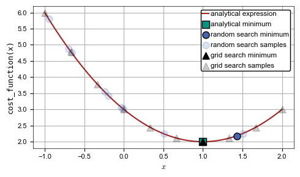

```python
# Import of needed packages
import numpy as np
import matplotlib.pyplot as plt
import mod.my_plotter as mp

# Initialize plot
monofont = {'fontname':'Monospace'}
mp.init_plot(scl_a4=1, page_lnewdth_cm=10, mrksze=8)

def cost_function(x):
    return (x-1)**2 + 2

# Calculate analytical experssion
x_a = np.linspace(-1,2,1000)
y_a = cost_function(x_a)

# Random search
num_iterations_rs = 10                      # Define number of iterations
x_min = -1                                  # Define search space minimum
x_max = 2                                   # Define search space maximum
x_samples_rs = np.zeros(num_iterations_rs)  # Keep track of sampled points
y_samples_rs = np.zeros(num_iterations_rs)  # Keep track of sampled points
# Search randomly until number of iterations is reached
for i in range(num_iterations_rs):
    # Generate random sampling point between x_min and x_max
    x_samples_rs[i] = np.random.uniform(x_min,x_max)
    # Evaluate this point
    y_samples_rs[i] = cost_function(x_samples_rs[i])
# Extract minimum index from samples
idx_min_rs = np.argmin(y_samples_rs)

# Grid search
num_iterations_gs = 10                      # Define number of iterations
x_min = -1                                  # Define search space minimum
x_max = 2                                   # Define search space maximum
x_samples_gs = np.linspace(x_min, x_max, num_iterations_gs)     # Generate (linearly spaced) sampling points
y_samples_gs = cost_function(x_samples_gs)  # Sample them!
idx_min_gs = np.argmin(y_samples_gs)           # Extract minimum index from samples

# Plot
fig, ax = plt.subplots(figsize=(5,3))
ax.plot(x_a, y_a, color=mp.red, zorder=1, label='analytical expression')
ax.scatter(1,2, edgecolors='k', marker='s', color=mp.green, linewidths=1, zorder=3, label='analytical minimum')
ax.scatter(x_samples_rs[idx_min_rs],y_samples_rs[idx_min_rs], edgecolors='k', marker='o', color=mp.blue, linewidths=1, zorder=4, label='random search minimum')
ax.scatter(x_samples_rs,y_samples_rs, marker='o', color=mp.blue, linewidths=1, zorder=2, alpha=0.2, label='random search samples')
ax.scatter(x_samples_gs[idx_min_gs],y_samples_gs[idx_min_gs], edgecolors='k', marker='^', color='k', linewidths=1, zorder=4, label='grid search minimum')
ax.scatter(x_samples_gs,y_samples_gs, marker='^', color='k', linewidths=1, zorder=2, alpha=0.2, label='grid search samples')

# Adjust plot style
ax.set_xlabel('$x$')
ax.set_ylabel('cost_function(x)', **monofont)
ax.legend(loc='upper right', fontsize='small', framealpha=1, ncol=1, labelspacing = 0.6)
ax.grid(True)
plt.tight_layout()
```

## 6.3 Gradient Descent and `scipy.optimize.minimize`

Both random and grid search will not *converge* into a minimum of the cost function. You might be lucky to hit it, but most of the time you will not be. Therefore we'd like to have a more sophisticated way of optimizing our function. A well-known and still simple to understand way of doing this is the so-called `gradient descent` method. Starting from an initial guess `x_0`, we calculate the gradient (derivative) of our cost function. In our example, we know the analytical expression of the derivative to be $\frac{\mathrm{d}y}{\mathrm{d}x}=2(x-1)$. In other cases, we may not know this, but can easily estimate the current derivative by finite differences (let's not worry about this for now). We now take a step in the direction of the *negative* gradient, i.e. visually, we take a step "downhill". The size of our step is decisive: Go too far and your optimizer will become unstable, go too little and you'll optimize forever. The *step size* or *learning rate* is often expressed as $\eta$ or `eta` and might be estimated depending on the current gradient. We will start by simply using a constant step size. Expressed as formula we can write

$$x_{i+1}=x_{i}-\eta\frac{\mathrm{d}y}{\mathrm{d}x}$$

In the code example below you'll see the most basic version of gradient descent implemented from scratch (make sure to run all cells above).

The beauty of Python is that a lot of smart people work on open source libraries that program more sophisticated versions of these algorithms (and better algorithms in general). One example is the method `minimize( )` of the `scipy.optimize` package ([documentation](https://docs.scipy.org/doc/scipy/reference/generated/scipy.optimize.minimize.html)). Let's look at the documentation and see how the method works. Note that I only show the most important parameters for now and that there are many more options e.g. to define bounds and constraints on the optimization problem.

`scipy.optimize.minimize(fun, x0, args=(), method=None)`

**Parameters:**

- `fun`: The objective function to minimize. The calling signature is `fun(x,args*)` (this means that the function has to take `x` as first input and `args*` after).
- `x_0`: Initial guess
- `args`: Additional arguments that can be passed to `fun`. They have to be given as tuple, i.e. `(value1, value2)` and need to be given in the correct order.
- `method`: Here you can choose which algorithm the method should use for optimization. Don't worry about this too much for now.

**Returns:**

The method returns an object that contains the actual information. It's most important properties are:

- `x`: The solution of the optimization
- `nit`: Number of iterations performed by the optimizer

In addition to our simple gradient descent method, we can solve the optimization problem with the `minimize` method, which saves us a lot of effort and makes the results more reliable. Note that everything related towards choosing an appropriate learning rate is integrated into the method and we don't have to worry about it. Sadly, `minimize` currently does not offer an option to save intermediate interations, so the final result has to do for now.

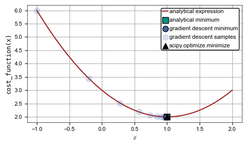

```python
# Import
from scipy.optimize import minimize

# Function to return the gradient at a given x-value.
# Note: If no analytical expression is known, we can calculate the gradient numerically
def calc_gradient(x):
    return 2*(x-1)

# Simple gradient descent
num_iterations_gd = 10                          # Define number of iterations
eta = 0.2                                       # Define learning rate
x_samples_gd = np.zeros(num_iterations_gd+1)    # Keep track of sampled points
x_samples_gd[0] = -1                            # Define start point
# Go through all iterations
for i in range(num_iterations_gd):
    # Take a step based on our constant learning rate and the current gradient
    x_samples_gd[i+1] = x_samples_gd[i] - eta*calc_gradient(x_samples_gd[i])
# Evaluate our x-values (only necessary for the plot)
# Note: Our minimum should be stored in the last entry
y_samples_gd = cost_function(x_samples_gd)

# Solve the optimization problem with scipy.optimize.minimize
opt_res = minimize(fun=cost_function, x0=-1)

# Plot
fig, ax = plt.subplots(figsize=(5,3))
ax.plot(x_a, y_a, color=mp.red, zorder=1, label='analytical expression')
ax.scatter(1,2, edgecolors='k', marker='s', color=mp.green, linewidths=1, zorder=3, label='analytical minimum')
ax.scatter(x_samples_gd[-1],y_samples_gd[-1], edgecolors='k', marker='o', color=mp.blue, linewidths=1, zorder=4, label='gradient descent minimum')
ax.scatter(x_samples_gd,y_samples_gd, marker='o', color=mp.blue, linewidths=1, zorder=2, alpha=0.2, label='gradient descent samples')
# The optimum is saved in opt_res.x and still needs to be evaluated
ax.scatter(opt_res.x,cost_function(opt_res.x), edgecolors='k', marker='^', color='k', linewidths=1, zorder=4, label='scipy.optimize.minimize')

# Adjust plot style
ax.set_xlabel('$x$')
ax.set_ylabel('cost_function(x)', **monofont)
ax.legend(loc='upper right', fontsize='small', framealpha=1, ncol=1, labelspacing = 0.6)
ax.grid(True)
plt.tight_layout()
```

## 6.4 A Quick Note on Global Versus Local Optimization

Gradient descent methods (`scipy.optimize.minimize` is one of them) are considered **local optimzers**. This means that they start a a specific point and go "downhill" until they reach a minimum. However, many functions (especially in real-world applications) are not as nice as the example above and have multiple local minima. Imagine this as a landscape with multiple valleys. Local optimizers will only find the valley closest to them (where they are led to by the gradient) which more often than not is not the "deepest" valley i.e. the **global minimum**. In order to find a global minimum, you have two choices:

1. Still use local optimizers, but varying the initial starting point
2. Use a so-called **global optimizer**

> ***Note:*** In more complicated problems it is impossible to know that you actually found a global (and not just a local) minimum. The best you can do is perform the optimization repeatedly for varying starting points, parameters and algorithms and evaluate the best results that you were able to find.

Let's explore this problem by minimizing the function $y = x^4 + 0.05x^3 - 4x^2 - 0.5x$. This function has two local minima at around $x_1\approx-1.4$ and $x_2\approx 1.43$, while $x_2$ is the true (global) minimum. We will set the initial guess to `x0 = -2` and apply both the `minimize` method from above (local optimizer) as well as the `basinhopping` method (global optimizer, see homework or [documentation](https://docs.scipy.org/doc/scipy/reference/generated/scipy.optimize.basinhopping.html)). As you can see, `minimize` only found the local minimum closest to the initial guess, while the global optimizer was more successful. Change `x0` to a different value closer to $x_2$ and see what happens!

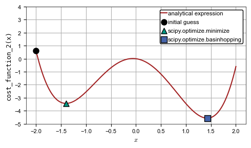

```python
from scipy.optimize import basinhopping

def cost_function_2(x):
    return x**4 + 0.05*x**3 - 4*x**2 - 0.5*x

# Calculate analytical experssion
x_a_2 = np.linspace(-2,2,1000)
y_a_2 = cost_function_2(x_a_2)

# Optimization
x0 = -2                                         # Starting point (initial guess)
opt_res = minimize(fun=cost_function_2, x0=x0)  # scipy.optimize.minimize
opt_res_bh = basinhopping(func=cost_function_2, x0=x0, niter=100, stepsize=2)   # scipy.optimize.basinhopping

# Plot
fig, ax = plt.subplots(figsize=(5,3))
ax.plot(x_a_2, y_a_2, color=mp.red, zorder=1, label='analytical expression')
ax.scatter(x0,cost_function_2(x0), edgecolors='k', marker='o', color='k', linewidths=1, zorder=4, label='initial guess')
ax.scatter(opt_res.x,cost_function_2(opt_res.x), edgecolors='k', marker='^', color=mp.green, linewidths=1, zorder=4, label='scipy.optimize.minimize')
ax.scatter(opt_res_bh.x,cost_function_2(opt_res_bh.x), edgecolors='k', marker='s', color=mp.blue, linewidths=1, zorder=4, label='scipy.optimize.basinhopping')

# Adjust plot style
ax.set_xlabel('$x$')
ax.set_ylabel('cost_function_2(x)', **monofont)
ax.legend(loc='upper right', fontsize='small', framealpha=1, ncol=1, labelspacing = 0.6)
ax.set_ylim([-5, 4])
ax.grid(True)
plt.tight_layout()
```

## 6.5 Linear Regression via Optimization

As you probably have guessed, we want to *optimize* the parameters $slope$ and $offset$ of the linear model $c^{*} = slope \cdot A^{*} + offset$. In this context, optimizing means that our modeled concentration values $c^{*}$ should fit the experimental values $c_{exp}$ best, i.e. that the difference between $c^{*}$ and $c_{exp}$ should be **minimized**.

**Note:** Quantifying the difference between the two arrays $c^{*}$ and $c_{exp}$ can be done in various ways! We - the scientists / engineers - have to define which *quality criterion* / *score* / *regression metric* is used. This choice also influences the optimization result. Some common regression metrics are:

- The mean absolute error (MAE) $$ MAE = \frac{1}{n}\sum_1^n |c^{*}-c_{exp}| $$
- The root mean squared error (RMSE) $$ RMSE = \sqrt{\frac{1}{n}\sum_1^n (c^{*}-c_{exp})^2} $$
- The coefficient of determination $R^2$ (see chapter 6 and note: the $R^2$ has to maximized)

Our strategy is as follows:

1. Define a **cost function** called `cf_lin_reg()`
   1. The inputs are: $slope$, $offset$, $A_{exp}$ (our x-data) and $c_{exp}$ (our *"true"* y-data).

   **Note:** Because of the way `minimize` is structured, we have to combine all parameters that we want to optimize ($slope$ and $offset$) into a single array which we will call `param_to_opt`. This will be clear in a second. 2) Calculate $c^{*}$ based on the given values of $slope$ and $offset$ with the linear equation above. 3) Calculate the difference between $c^{*}$ and our *"true"* values $c_{exp}$. We will use the mean absolute error `MAE` as regression metric.
2. Read experimental Data $A_{exp}(c_{exp})$ (recycled from chapter 6)
3. Optimize `cf_lin_reg()` via `scipy.minimize()`

```
## The optimized parameters are:
####  slope =  8.974829928973885e-05
#### offset =  1.5804229984218202e-08
## The (optimized) mean absolute error is:  3.5147677709343904e-07
## The Coefficient of Determination (R2) is:  0.9992
```

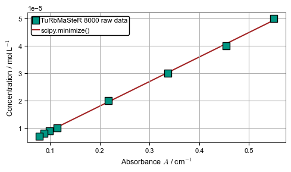

```python
# Import pandas
import pandas as pd

# Define the cost function.
# Note: Because of the way minimize is structured, param_to_opt is an array that contain slope and offset.
# Note2: cf_lin_reg requires additional parameters A_exp and c_exp. This has to be passed through the *args input as tuple (order!)
def cf_lin_reg(param_to_opt, *args):
    # Extract param_to_opt and *args for readability
    slope = param_to_opt[0]
    offset = param_to_opt[1]

    A_exp = args[0]
    c_exp = args[1]

    # Calculate c_mod with the linear equation
    c_mod = slope*A_exp + offset

    # Calculate the difference between c_mod and c_exp. Use MAE as regression metric
    MAE = np.mean(np.abs(c_mod - c_exp))

    return MAE

# Import A_exp and c_exp data (chapter 6)
# Define the path variable to excel file
path_to_xlsx = './data/calibration_caffeine_turbmaster/230626_caffeine-calib_lam_276.xlsx'
dataframe_excel = pd.read_excel(path_to_xlsx, sheet_name=0)
c_exp = dataframe_excel.iloc[1:,2].astype(float).values
A_exp = dataframe_excel.iloc[1:,3].astype(float).values

# Optimize for slope and offset via scipy.minimize()
# Note: param_to_opt is an array and therefore x0 (initial guess) also needs to be an array
# Note2: cf_lin_reg requires A_exp and c_exp as additional parameters, which are passed through *args argument
opt_res = minimize(fun=cf_lin_reg, x0=np.array([1,1]), args=(A_exp, c_exp))
# Extract results. opt_res.x contains the optimized values of param_to_opt --> Extract slope and offset
slope_opt = opt_res.x[0]
offset_opt = opt_res.x[1]
A_opt = np.linspace(min(A_exp),max(A_exp),1000)
c_opt = slope_opt*A_opt + offset_opt
# Calculate MAE and R2 because we can
c_mod = slope_opt*A_exp + offset_opt
SS_tot = np.sum((c_exp-np.mean(c_exp))**2)
SS_res = np.sum((c_exp-c_mod)**2)
R2_opt = 1-(SS_res/SS_tot)
MAE_opt = cf_lin_reg(opt_res.x, A_exp, c_exp)

# Print results
print('## The optimized parameters are: ')
print('####  slope = ', f'{slope_opt}')
print('#### offset = ', f'{offset_opt}')
print('## The (optimized) mean absolute error is: ', f'{MAE_opt}')
print('## The Coefficient of Determination (R2) is: ', f'{np.round(R2_opt,4)}')

# Plot data
fig, ax = plt.subplots(figsize=(5,3))
# Data
ax.scatter(x=A_exp, y=c_exp,
           edgecolors='k', marker='s', color=mp.green, linewidths=1,
           zorder=1, label='TuRbMaSteR 8000 raw data')
ax.plot(A_opt, c_opt, color=mp.red, zorder=0, label='scipy.minimize()')

# Plot setup
ax.set_ylabel('Concentration / mol$\,$L$^{-1}$')
ax.set_xlabel('Absorbance $A$ / cm$^{-1}$')
ax.legend(loc='upper left', fontsize='small', framealpha=1, ncol=1, labelspacing = 0.6)
ax.grid(True)
plt.tight_layout()
```

## 6.6 Final Notes

Optimization is a very interesting and multilayered problem. By now, you hopefully have a basic understanding of how different types of optimization algorithms work. It cannot be stressed enough, that there is **no one-size-fits-all optimizer**, i.e. there is not a single algorithm that is superior to other algorithms. All optimizers have pros and cons and are useful in different scenarios! Some important selction criteria you should think about before choosing an optimizer include:

- Is the derivative known? $\rightarrow$ Makes gradient descent more attractive
- Is the cost function hard (expensive) to compute? $\rightarrow$ Some algorithms require less evaluations
- Are there multiple local minima and you want to find the global minimum? $\rightarrow$ Discussed above

Obviously, all these points are too much to cover in detail here! But note, that choosing the correct (optimal) optimization algorithm is highly problem- and data-dependent. So ultimately, you will have to try different optimizers and see which work best for your purpose. Basically, you need to optimize you optimizer before optimizing the actual problem (: